# Practical 4

Matteo Larrode

2024-02-05

### Exercice 1: Karate Club

```r
library(igraph)
library(igraphdata)

data(karate)
```

```
## This graph was created by an old(er) igraph version.
##   Call upgrade_graph() on it to use with the current igraph version
##   For now we convert it on the fly...
```

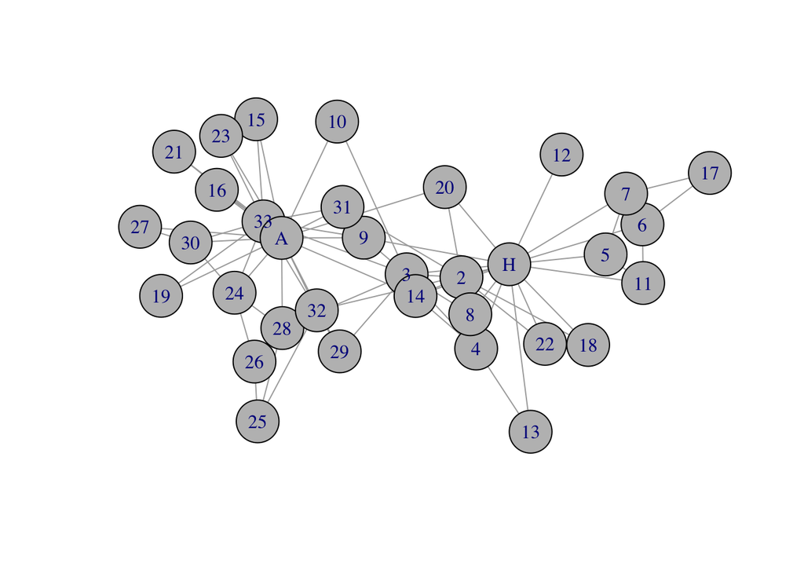

```r
set.seed(12345)
plot.igraph(karate, vertex.color="gray", asp=0)
```

More information about the network:

```r
is.directed(karate)
```

```
## [1] FALSE
```

```r
is.weighted(karate)
```

```
## [1] TRUE
```

```r
E(karate)$weight
```

```
##  [1] 4 5 3 3 3 3 2 2 2 3 1 3 2 2 2 2 6 3 4 5 1 2 2 2 3 4 5 1 3 2 2 2 3 3 3 2 3 5
## [39] 3 3 3 3 3 4 2 3 3 2 3 4 1 2 1 3 1 2 3 5 4 3 5 4 2 3 2 7 4 2 4 2 2 4 2 3 3 4
## [77] 4 5
```

```r
V(karate)$name
```

```
##  [1] "Mr Hi"    "Actor 2"  "Actor 3"  "Actor 4"  "Actor 5"  "Actor 6"
##  [7] "Actor 7"  "Actor 8"  "Actor 9"  "Actor 10" "Actor 11" "Actor 12"
## [13] "Actor 13" "Actor 14" "Actor 15" "Actor 16" "Actor 17" "Actor 18"
## [19] "Actor 19" "Actor 20" "Actor 21" "Actor 22" "Actor 23" "Actor 24"
## [25] "Actor 25" "Actor 26" "Actor 27" "Actor 28" "Actor 29" "Actor 30"
## [31] "Actor 31" "Actor 32" "Actor 33" "John A"
```

Centrality of top 5 actors:

```r
sort(degree(karate), decreasing = TRUE)[1:5]
```

```
##   John A    Mr Hi Actor 33  Actor 3  Actor 2
##       17       16       12       10        9
```

```r
sort(strength(karate), decreasing = TRUE)[1:5]
```

```
##   John A    Mr Hi Actor 33  Actor 3  Actor 2
##       48       42       38       33       29
```

```r
sort(closeness(karate, weights = NA, normalized=TRUE), decreasing = TRUE)[1:5]
```

```
##     Mr Hi   Actor 3    John A  Actor 32   Actor 9
## 0.5689655 0.5593220 0.5500000 0.5409836 0.5156250
```

```r
sort(betweenness(karate, weights = NA, normalized=TRUE), decreasing = TRUE)[1:5]
```

```
##     Mr Hi    John A  Actor 33   Actor 3  Actor 32
## 0.4376353 0.3040750 0.1452471 0.1436568 0.1382756
```

```r
sort(eigen_centrality(karate, weights = NA)$vector, decreasing  = TRUE)[1:5] #already normalized
```

```
##    John A     Mr Hi   Actor 3  Actor 33   Actor 2
## 1.0000000 0.9521324 0.8495542 0.8266589 0.7123351
```

```r
sort(page.rank(karate, weights = NA)$vector, decreasing  = TRUE)[1:5] #already normalized
```

```
##     John A      Mr Hi   Actor 33    Actor 3    Actor 2
## 0.10091918 0.09699729 0.07169323 0.05707851 0.05287692
```

John A and Mr Hi are often the top two characters in terms of different centrality scores. Actors 33 and 3 are the other central nodes in the network after John A and Mr Hi according to those different centrality measures. Actor 3 outranks John A with closeness centrality. This also makes sense, as Actor 3 occupies a position between the faction around A and H, and hence close to many other actors. Actor 2, Actor 32, and Actor 9 are other actors that make it to top 5. Again these actors seem to have ties with the faction around A and H.

We can now examine **coreness** of the network:

```r
C <- coreness(karate)
table(C)
```

```
## C
##  1  2  3  4
##  1 11 12 10
```

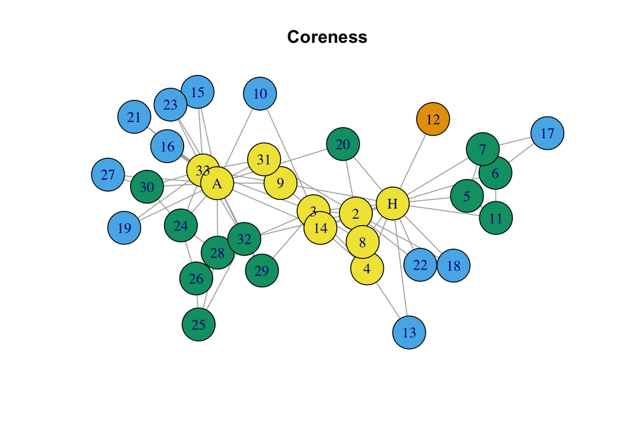

```r
set.seed(12345)
plot(karate, vertex.size=15, vertex.color=coreness(karate),  main='Coreness', asp=0)
```

The table(C) function shows that there are 10 members of the 4-core, 12 new members of the 3-core (in addition to those that are members of the 4-core), 11 new members of the 2-core (in addition to the members of the 3- and 4- cores that are by default members of the 2-core). There is only 1 actor who is not a member of the 2- or more-cores (actor 12).

The 4-core obviously is at the centre of the network. This contains John A and Mr Hi, as well as other central actors. Actor 12 seems like a hermit. Their only connection is to Mr Hi.

#### Blockmodeling and structural equivalence.

```r
library(blockmodeling)
```

```r
# First we need to extract the adjacency matrix in the matrix format from the karate graph object:
kar <- as.matrix(get.adjacency(karate))

#if you want to keep weights you can use this
kar2 <- as.matrix(get.adjacency(karate, attr="weight"))
```

We will run the blockmodelling for structural equivalence.

- We use the `optRandomParC()` function of the package. The function wants us to specify the number of “roles” or “blocks” beforehand using the k = option.
- `rep` is how many times should the algorithm repeat the blockmodelling (then the algorithm selects the best partion among that many repetitions).
- algorithm also has many optimization options under `approach`. For now, we will keep it at “ss” which is sum of squares
- The final option we will need to specify is blocks. The function allows many types of blocks. This is because the function is programmed more generally, to deal with other types of blockmodeling (e.g. regular equivalence etc.). We will use the blocks = “com” option. This instructs R to find a solution to try to come up with “complete” blocks which are composed of all 1’s as much as possible (hence other blocks will have to be composed of 0s).

We will be running blockmodeling with 2, 3, 4 blocks.

*Note: some versions of the `blockmodeling` package doesn’t have the `optRandomParC()` function but instead `opt.random.par()` for the same function*

```r
Kclass2 <- optRandomParC(M=kar, k=2, rep=10, approach="ss", blocks = "com")
```

[output not shown]

[output cut: 9 more lines]

```
##
## Starting optimization of the partiton 9 of 10 partitions.
## Starting partition: 2 1 1 1 1 1 2 1 1 2 1 1 2 1 2 1 2 2 2 2 1 1 1 1 1 2 1 1 2 2 2 1 2 1
## Final error: 109.001
## Final partition:    2 2 2 1 1 1 1 1 1 1 1 1 1 1 1 1 1 1 1 1 1 1 1 1 1 1 1 1 1 1 1 1 2 2
##
##
## Starting optimization of the partiton 10 of 10 partitions.
## Starting partition: 1 1 1 1 1 1 1 1 1 1 1 1 1 1 1 1 1 2 1 1 1 1 1 1 1 1 1 1 1 1 1 1 1 1
## Final error: 109.001
## Final partition:    1 1 1 2 2 2 2 2 2 2 2 2 2 2 2 2 2 2 2 2 2 2 2 2 2 2 2 2 2 2 2 2 1 1
##
##
## Optimization of all partitions completed
## 1 solution(s) with minimal error = 109.001 found.
```

```r
Kclass3 <- optRandomParC(M=kar, k=3, rep=10, approach="ss", blocks = "com")
```

[output not shown]

[output cut: 9 more lines]

```
##
## Starting optimization of the partiton 9 of 10 partitions.
## Starting partition: 2 2 2 3 2 2 2 2 2 2 2 1 2 2 2 2 2 2 2 2 2 2 2 2 2 2 2 2 2 2 2 2 2 2
## Final error: 96.45795
## Final partition:    3 3 3 3 2 2 2 3 2 2 2 2 2 3 2 2 2 2 2 2 2 2 2 2 2 2 2 2 2 2 2 2 1 1
##
##
## Starting optimization of the partiton 10 of 10 partitions.
## Starting partition: 1 1 1 1 1 1 2 1 1 1 1 1 1 1 1 1 1 1 1 1 1 1 1 1 1 1 1 1 1 1 3 1 1 1
## Final error: 99.2026
## Final partition:    2 2 2 1 3 3 3 1 1 1 3 1 1 1 1 1 3 1 1 1 1 1 1 1 3 3 1 1 1 1 1 1 2 2
##
##
## Optimization of all partitions completed
## 1 solution(s) with minimal error = 95.23754 found.
```

```r
Kclass4 <- optRandomParC(M=kar, k=4, rep=10, approach="ss", blocks = "com")
```

[output not shown]

[output cut: 9 more lines]

```
##
## Starting optimization of the partiton 9 of 10 partitions.
## Starting partition: 2 3 3 3 1 3 1 3 1 1 4 4 1 3 2 3 4 4 1 4 2 4 4 3 3 1 2 3 2 2 2 4 4 4
## Final error: 77.61472
## Final partition:    1 1 1 1 4 4 4 1 2 2 4 4 4 1 2 2 4 4 2 2 2 4 2 2 4 4 2 2 2 2 2 2 3 3
##
##
## Starting optimization of the partiton 10 of 10 partitions.
## Starting partition: 2 2 2 2 2 1 2 2 2 2 2 2 2 2 2 2 2 4 2 2 2 2 2 2 2 2 2 2 2 2 2 3 2 2
## Final error: 98.73804
## Final partition:    1 1 4 2 2 2 2 2 3 3 2 2 2 3 2 2 2 2 2 2 2 2 2 2 2 2 2 3 3 2 2 2 1 4
##
##
## Optimization of all partitions completed
## 1 solution(s) with minimal error = 77.61472 found.
```

We now have the results of blockmodelling stored as objects Kclass2, Kclass3, and Kclass4. We will now plot the adjacency matrix with those solutions.

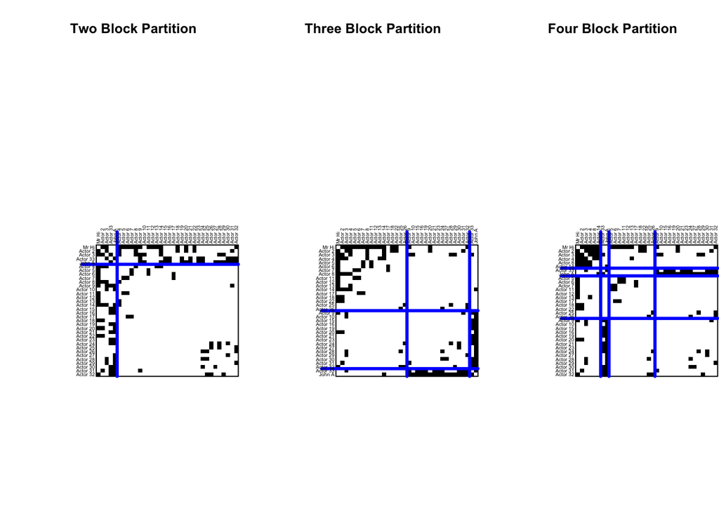

```r
par(mfrow=c(1,3)) # set the plot window for one row and three columns

plot(Kclass2, main="")
title("Two Block Partition")

plot(Kclass3, main="")
title("Three Block Partition")

plot(Kclass4, main="")
title("Four Block Partition")
```

In each solution, R rearranged the adjacency matrix to make block either all blacks or all whites, as much as possible. Those would then be separate blocks, i.e. structurally equivalent actors.

We can plot the network with the nodes coloured based on the result of blockmodeling, which makes it easier to inspect the results.

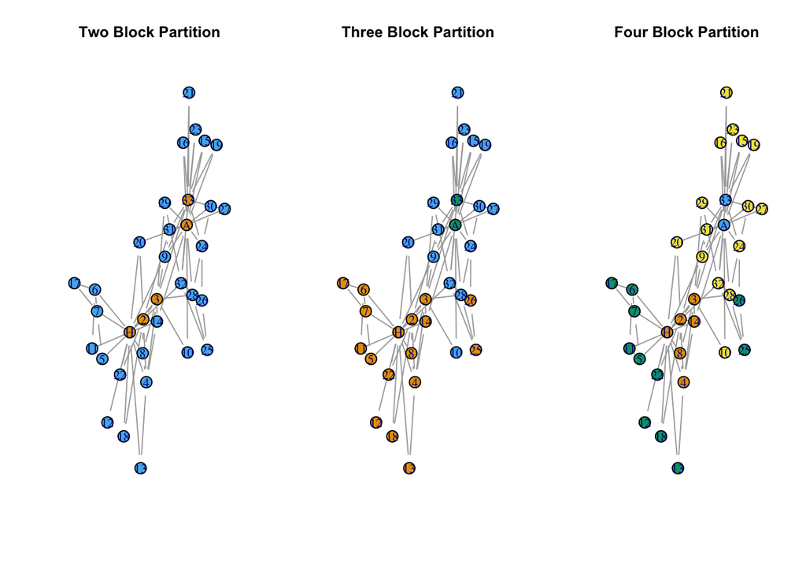

```r
l <- layout_with_fr(karate) #creating one layout and saving it as object "l".
par(mfrow=c(1,3))

#result of two blocks:
plot(karate, vertex.size=15, vertex.color=Kclass2$best$best1$clu, layout = l, asp=0)
title("Two Block Partition")

#result of three blocks:
plot(karate, vertex.size=15, vertex.color=Kclass3$best$best1$clu, layout = l, asp=0)
title("Three Block Partition")

#result of four blocks:
plot(karate, vertex.size=15, vertex.color=Kclass4$best$best1$clu, layout = l, asp=0)
title("Four Block Partition")
```

In the two block partition, there is a core/periphery structure. John A, Mr Hi, 33, 3, and 2 (all central actors) are structurally (approximately) equal. The periphery (blues) are structurally equivalent to each other–i.e. they play a similar social “role”.

In the three block case, we have John A and his sidekick person 33 who seem to play the same role as John A. We then have Mr Hi and his immediate clique around who are deemed to play similar roles in the network. It is difficult to imagine that, Mr Hi and Actor 12 are structurally equivalent, and play similar roles. So the three block solution is less sensible than the two block solution. The three block partition also identifies a periphery around John A and Actor 33.

The four block partition is also rather sensible. John A and his sidekick Actor 33 are one block. So given that John A is the president, one may speculate that Actor 33 could stand for John A in administrative stuff. We then have Mr Hi and people immediately around him who are also central in the network as another block. This block around Mr Hi can be thought of having a role of “instructors”, given that Mr Hi is the chief instructor–though this is completely speculative. Then the four block partition identifies two further blocks, a periphery around John A and another around Mr Hi.

### Exercice 2: Groups of Nodes in SOCS0081 data

#### Cliques in the course

```r
N <- read.csv("data/net_anon24.csv", header = TRUE)
c <- read.csv("data/courses24.csv", header = TRUE)

gn <- graph.data.frame(N, directed = TRUE) + vertices(25, 16, 34, 64, 99, 54, 113)

#selecting and ordering courses according tho the node order and set in V(gn)
c <- c[as.numeric((V(gn)$name)),]

gn <- set_vertex_attr(gn, "course", value = c$course)
```

First, we can identify the largest cliques in the class:

```r
lc <- largest_cliques(gn)
lc
```

```
## [[1]]
## + 6/110 vertices, named, from 9d030bd:
## [1] 50 22 88 80 53 42
```

The largest clique has 6 members which is composed of POLS students. We can visualise it.

```r
set.seed(1)
lf <-layout.fruchterman.reingold(gn)

V(gn)$clique <- ifelse(V(gn) %in% c(largest_cliques(gn)[[1]]), 1, 0)
```

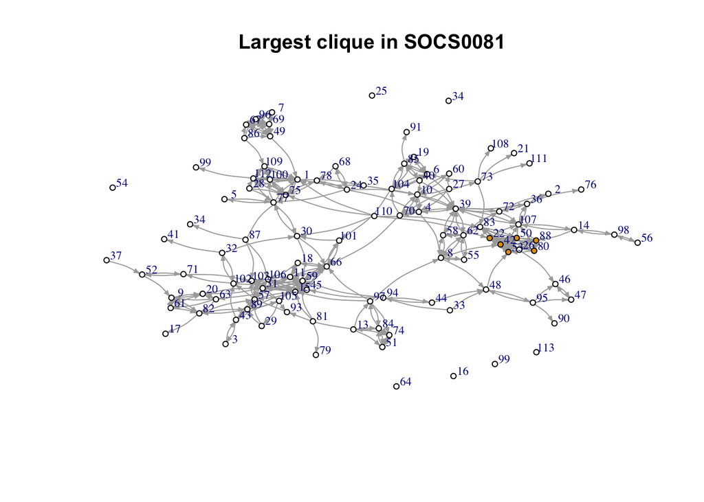

```r
plot(gn,
     vertex.size= 2,
     edge.arrow.size = 0.3,
     vertex.label.cex = 0.7,
     edge.curved=.2, asp = 0,
     layout = lf,
     vertex.label.dist=0.7,
     vertex.color = V(gn)$clique,
     main = "Largest clique in SOCS0081")
```

While there is a single largest clique of 6, there are several other cliques of size 5:

```r
print(cliques(gn, min = 5, max = 100))
```

```
## [[1]]
## + 5/110 vertices, named, from 9d030bd:
## [1] 22 42 53 80 88
##
## [[2]]
## + 5/110 vertices, named, from 9d030bd:
## [1] 22  42  53  88  107
##
## [[3]]
## + 5/110 vertices, named, from 9d030bd:
## [1] 1   75  100 109 112
##
## [[4]]
## + 5/110 vertices, named, from 9d030bd:
## [1] 7  49 67 69 96
##
## [[5]]
## + 5/110 vertices, named, from 9d030bd:
## [1] 49 67 69 86 96
##
## [[6]]
## + 5/110 vertices, named, from 9d030bd:
## [1] 22 50 53 80 88
##
## [[7]]
## + 6/110 vertices, named, from 9d030bd:
## [1] 22 42 50 53 80 88
##
## [[8]]
## + 5/110 vertices, named, from 9d030bd:
## [1] 42 50 53 80 88
##
## [[9]]
## + 5/110 vertices, named, from 9d030bd:
## [1] 22 42 50 53 80
##
## [[10]]
## + 5/110 vertices, named, from 9d030bd:
## [1] 22 42 50 80 88
##
## [[11]]
## + 5/110 vertices, named, from 9d030bd:
## [1] 22 42 50 53 88
```

We can plot them the same way as before:

```r
V(gn)$clique5 <- ifelse(V(gn) %in% unlist(cliques(gn, min = 5, max = 100)), 1, 0)
```

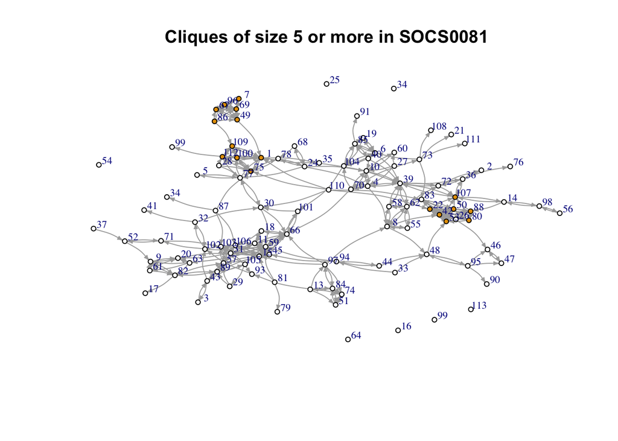

```r
#we are using the unlist() function to extract all elements of list into a single vector

plot(gn,
     vertex.size= 2,
     edge.arrow.size = 0.3,
     vertex.label.cex = 0.7,
     edge.curved=.2, asp = 0,
     layout = lf,
     vertex.label.dist=0.7,
     vertex.color = V(gn)$clique5,
     main = "Cliques of size 5 or more in SOCS0081")
```

Note that R ignores the direction in ties in identifying cliques. This perhaps makes sense, as otherwise (i.e. defining cliques with direction requiring everyone in the clique to be linked with everyone else both directions), the cliques would be very small and would not give sensible results.

#### Coreness in the course

**Coreness list (largest core in which each node belongs):**

```r
coreness(gn)
```

```
##   1   3   4   5   6   7   8   9  10  11  13  14  15  18  19  20  22  24  26  27
##   6   2   6   2   6   5   6   5   6   6   5   3   6   5   5   5   7   4   7   3
##  28  29  30  31  32  33  35  36  37  39  40  42  43  44  45  46  47  48  49  50
##   4   3   5   6   3   2   3   5   1   6   6   7   4   3   6   3   3   3   6   7
##  51  52  53  55  56  57  58  59  60  61  62  63  66  67  68  69  70  71  72  73
##   5   3   7   4   2   6   6   6   3   5   6   5   6   6   3   6   6   3   5   3
##  74  75  77  78  80  81  82  83  84  85  86  87  88  89  93  94  95  96  97  98
##   5   6   5   4   7   2   5   7   5   6   5   3   7   5   3   3   3   6   5   2
## 100 101 102 103 104 105 106 107 109 110 112  41   2  76  21 108 111  79  17  91
##   6   5   3   6   6   4   6   6   6   5   6   1   2   1   1   1   1   1   1   1
##  34  90  99  25  16  34  64  99  54 113
##   1   1   1   0   0   0   0   0   0   0
```

**Number of nodes in each coreness:**

```r
table(coreness(gn))
```

```
##
##  0  1  2  3  4  5  6  7
##  7 12  7 19  6 21 30  8
```

**Which nodes belongs to the largest k-core:**

```r
coreness(gn)[coreness(gn) == max(coreness(gn))]
```

```
## 22 26 42 50 53 80 83 88
##  7  7  7  7  7  7  7  7
```

**Tabulating coreness with course:**

```r
table(coreness(gn), V(gn)$course)
```

```
##
##     Other Pols SocSS SSDS
##   0     4    0     2    1
##   1     1    3     4    4
##   2     2    2     2    1
##   3     7    1     2    9
##   4     1    0     1    4
##   5     9    2     4    6
##   6     9    1     8   12
##   7     0    8     0    0
```

The largest k-core here is a 7-core which has 8 individuals in it. So each of these 8 individuals is joined to at least 7 others in this network. The individuals in this 7-core are: 22, 26, 42, 50, 53, 80, 83, 88. This again corresponds to the group of people who formed the dense cliques within the Pols faction of the SOCS0081 network. There is also a 6-core with 30 individuals. This 6-core spans mainly the SSDS folks but also SocSS and Other.

We can visualise the coreness of the programme:

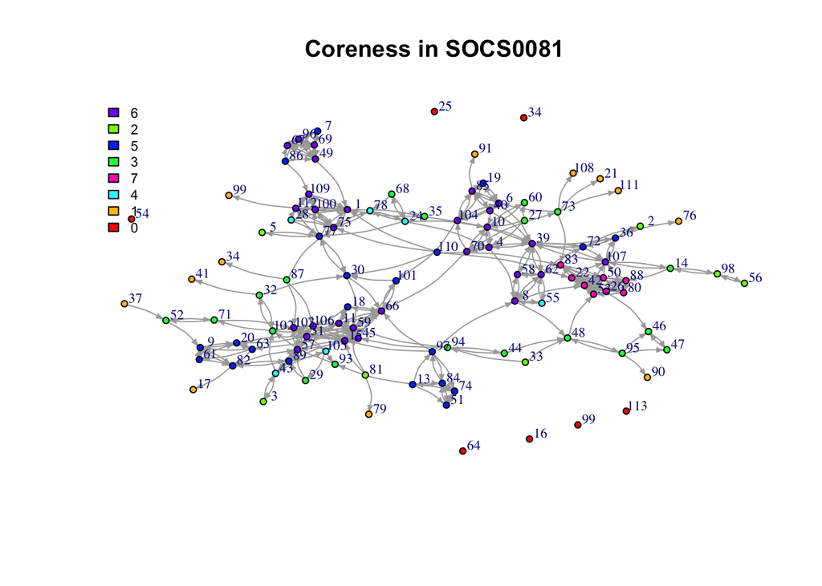

```r
plot(gn,
     vertex.size= 2,
     edge.arrow.size = 0.3,
     vertex.label.cex = 0.7,
     edge.curved=.2,
     asp = 0, layout = lf,
     vertex.label.dist=0.7,
     vertex.color =rainbow(8)[as.factor(coreness(gn))],
     main = "Coreness in SOCS0081")

legend("topleft",
       bty = "n",
       legend=unique(as.factor(coreness(gn))),
       cex = 0.7,
       fill = rainbow(8)[unique(as.factor(coreness(gn)))]
       )
```

#### Blockmodeling of SOCS0081 Network

We will try blockmodels with 5, 6, and 7 blocks.

```r
MS <- as.matrix(gn) #turning gn network into a matrix needed for blockmodelling

c5 <- optRandomParC(M=MS, k=5, rep=10, approach="ss", blocks="com")
c6 <- optRandomParC(M=MS, k=6, rep=10, approach="ss", blocks="com")
c7 <- optRandomParC(M=MS, k=7, rep=10, approach="ss", blocks="com")
```

Time for visualisation!

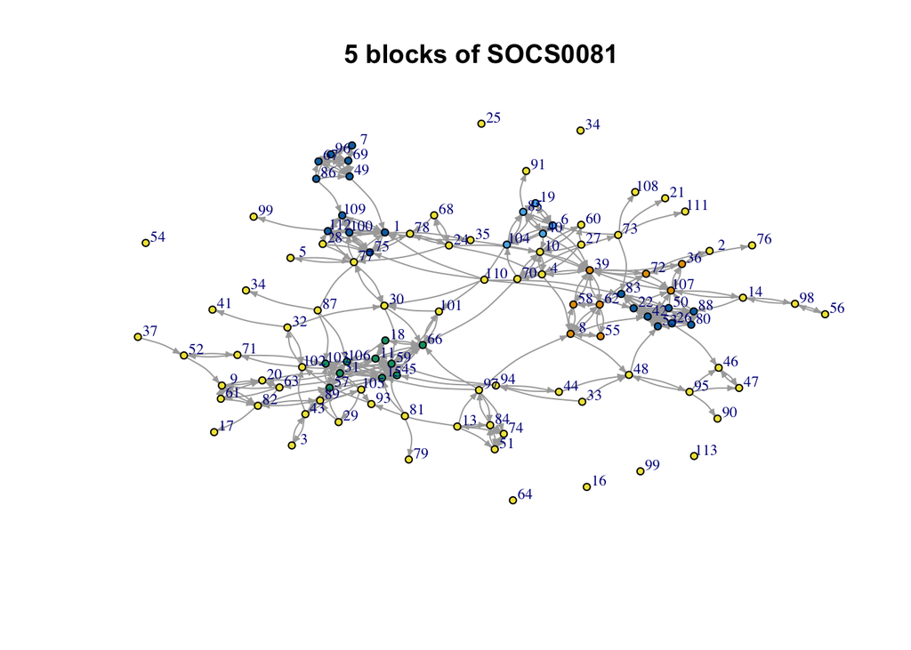

```r
plot(gn,
     vertex.size= 2,
     edge.arrow.size = 0.3,
     vertex.label.cex = 0.7,
     edge.curved=.2,
     asp = 0, layout = lf,
     vertex.label.dist=0.7,
     vertex.color = c5$best$best1$clu,
     main = "5 blocks of SOCS0081",
     margin=c(0,0,0,0))
```

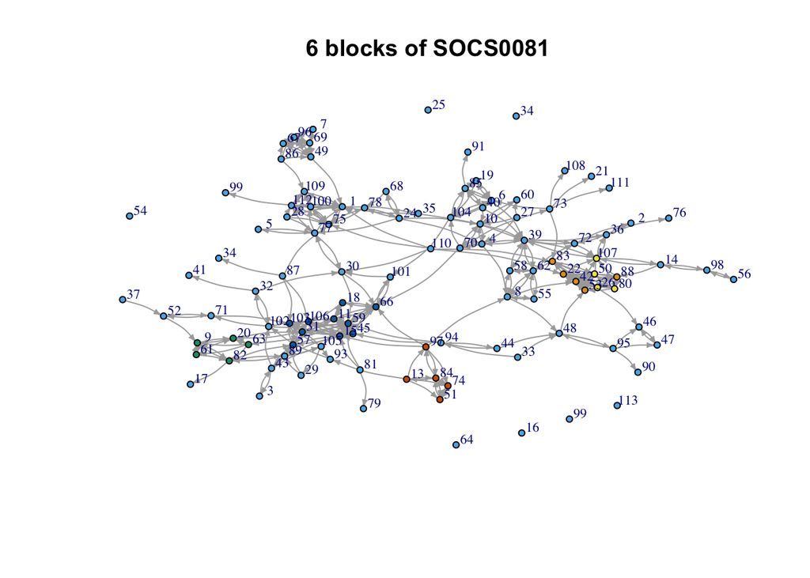

```r
plot(gn,
     vertex.size= 2,
     edge.arrow.size = 0.3,
     vertex.label.cex = 0.7,
     edge.curved=.2,
     asp = 0, layout = lf,
     vertex.label.dist=0.7,
     vertex.color = c6$best$best1$clu,
     main = "6 blocks of SOCS0081",
     margin=c(0,0,0,0))
```

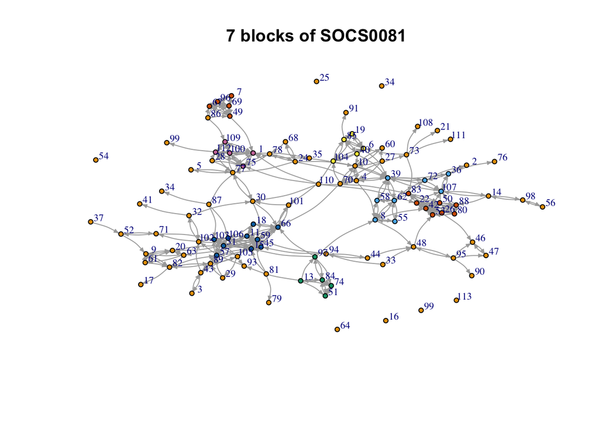

```r
plot(gn,
     vertex.size= 2,
     edge.arrow.size = 0.3,
     vertex.label.cex = 0.7,
     edge.curved=.2,
     asp = 0, layout = lf,
     vertex.label.dist=0.7,
     vertex.color = c7$best$best1$clu,
     main = "7 blocks of SOCS0081",
     margin=c(0,0,0,0))
```

Let’s tabulate the course with the 5-block solution:

```r
table(c5$best$best1$clu, V(gn)$course)
```

```
##
##     Other Pols SocSS SSDS
##   1     0    3     0    5
##   2     0    0     0    5
##   3     0    0     8    2
##   4    22    6    15   25
##   5    11    8     0    0
```

We can even test the relationship between course and structural equivalence formally:

```r
chisq.test(table(c5$best$best1$clu, V(gn)$course))
```

```
##
##  Pearson's Chi-squared test
##
## data:  table(c5$best$best1$clu, V(gn)$course)
## X-squared = 66.557, df = 12, p-value = 1.403e-09
```

The cross-tab of the 5-blocks with the course shows interesting patterns. The “other” folks are placed across two blocks only, one the centre and the other on the periphery. SSDS folks are distributed across four blocks, first one with a more periphery with 25 members, and other core groups. This shows that SSDS students occupy several different network roles. SocSS students are distributed across two blocks, again one core and another periphery. The chi-square test of the cross-table of course with the 5-blocks show that there is a statistically highly significant relationship between course and the network ``roles” in the network of SOCS0081, perhaps supporting our interpretations of the differences between the distribution of course members across blocks (if the chi-sq test was insignificant, that would mean the members of the four courses were roughly equally distributed across the 5-blocks but this hypothesis is rejected).